# Machine Learing

## 1- Simple Linear Regression

```python
import pandas as pd
import numpy as np
import matplotlib.pyplot as plt
```

### STEP-1 Data Set

```python
df = pd.read_csv('ml_data_salary.csv')
df.head(5)
```

|  | age | distance | YearsExperience | Salary |
| --- | --- | --- | --- | --- |
| 0 | 31.1 | 77.75 | 1.1 | 39343 |
| 1 | 31.3 | 78.25 | 1.3 | 46205 |
| 2 | 31.5 | 78.75 | 1.5 | 37731 |
| 3 | 32.0 | 80.00 | 2.0 | 43525 |
| 4 | 32.2 | 80.50 | 2.2 | 39891 |

### STEP-3 Sellecting X & Y Values from Data SET

```python
x = df[['YearsExperience']]
y= df[['Salary']]
```

```python
x.head()
```

|  | YearsExperience |
| --- | --- |
| 0 | 1.1 |
| 1 | 1.3 |
| 2 | 1.5 |
| 3 | 2.0 |
| 4 | 2.2 |

#### Import Model or Selection of Model & Split6 Data Set

```python
# Import Model
from sklearn.model_selection import train_test_split
from sklearn.linear_model import LinearRegression
```

```python
x_train,x_test, y_train,y_test = train_test_split(x,y, test_size=0.2,random_state=0)
```

### STEP-4 Fit Linear Regression Model

```python
model = LinearRegression().fit(x_train,y_train)
model
```

```
LinearRegression()
```

### STEP-5 Draw Plot

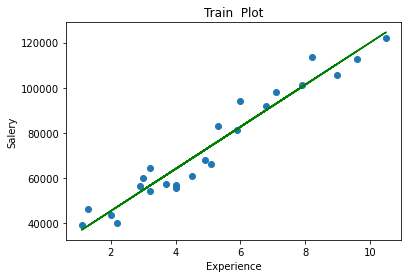

```python
plt.scatter(x_train,y_train)
plt.plot(x_train,model.predict(x_train),color='Green')
plt.xlabel('Experience')
plt.ylabel('Salery')
plt.title('Train  Plot')
plt.show()
```

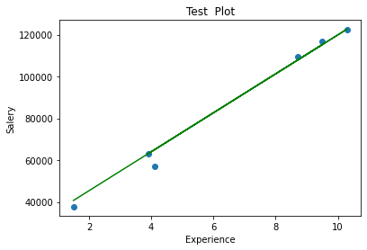

```python
plt.scatter(x_test,y_test)
plt.plot(x_test,model.predict(x_test),color='Green')
plt.xlabel('Experience')
plt.ylabel('Salery')
plt.title('Test  Plot')
plt.show()
```

### STEP-5 Testing Or Evaluation Ypur Model

```python
# Model Fittness
model.score(x_test,y_test),model.score(x_train,y_train)
```

```
(0.988169515729126, 0.9411949620562126)
```

### STEP_6 Prediction of Unknow Values

```python
model.predict([[10],[5],[3],[1]])
```

```
array([[119905.85041792],
       [ 73342.97478427],
       [ 54717.82453082],
       [ 36092.67427736]])
```

```python
model.predict(x_test)
```

```
array([[ 40748.96184072],
       [122699.62295594],
       [ 64961.65717022],
       [ 63099.14214487],
       [115249.56285456],
       [107799.50275317]])
```

# Machine Learing

## 02- Multiple Linear Regression

### STEP-1 Importing Libraries

```python
import pandas as pd
import numpy as np
import matplotlib.pyplot as plt
import seaborn as sns
from sklearn.linear_model import LinearRegression
```

### STEP-2 Importing Data Set

```python
df = pd.read_csv('ml_data_salary.csv')
df.head(5)
```

|  | age | distance | YearsExperience | Salary |
| --- | --- | --- | --- | --- |
| 0 | 31.1 | 77.75 | 1.1 | 39343 |
| 1 | 31.3 | 78.25 | 1.3 | 46205 |
| 2 | 31.5 | 78.75 | 1.5 | 37731 |
| 3 | 32.0 | 80.00 | 2.0 | 43525 |
| 4 | 32.2 | 80.50 | 2.2 | 39891 |

### STEP-3 Sellecting X & Y Values from Data SET

```python
# x = df[['age','distance','YearsExperience']]
x = df[['age','distance','YearsExperience']]
y= df[['Salary']]
```

```python
x.head()
```

|  | age | distance | YearsExperience |
| --- | --- | --- | --- |
| 0 | 31.1 | 77.75 | 1.1 |
| 1 | 31.3 | 78.25 | 1.3 |
| 2 | 31.5 | 78.75 | 1.5 |
| 3 | 32.0 | 80.00 | 2.0 |
| 4 | 32.2 | 80.50 | 2.2 |

```python
from sklearn.model_selection import train_test_split
x_train,x_test, y_train,y_test = train_test_split(x,y, test_size=0.2,random_state=0)
```

### STEP-4 Creating a Model and Fit Model on X & Y

```python
model = LinearRegression().fit(x,y)
model
```

```
LinearRegression()
```

### Finding Coefficient & Intercept Value

```python
print('Coefficient Values for this Regression are',model.coef_)
```

```
Coefficient Values for this Regression are [[-2.68055892e+15  1.06092560e+15  2.82449143e+13]]
```

```python
print('Intercept Values for this Regression are', model.intercept_)
```

```
Intercept Values for this Regression are [8.4734743e+14]
```

```python
# Send Audio Message Video minute 8;36
# Now we have to give 3 variable Values like(Age,Distance,Experience) in 2-d Array
# pridict_salery=model.predict([[31.1,77.75,1.1]])
pridict_salery=model.predict(x_test)
print('Pridicted Salery Based on All thre Perameter is :-',pridict_salery)
```

```
Pridicted Salery Based on All thre Perameter is :- [[ 39995.25]
 [123160.25]
 [ 64552.5 ]
 [ 62679.5 ]
 [115604.25]
 [108032.  ]]
```

```python
# Assignment  is How to plot Multiple Linear Regression
# How to Test the efficancy of model?
```

**Mean Squared Error**

```python
from sklearn.metrics import mean_squared_error
mean_squared_error(y_test,pridict_salery)
```

```
10941935.28125
```

```python
from sklearn.metrics import r2_score
r2_score(y_test,pridict_salery)
```

```
0.9899053083353905
```

### Plotting Our Model

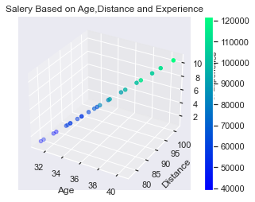

```python
sns.set()
fig = plt.figure()
ax = fig.add_subplot(111,projection='3d')
x = x_train['age']
y = x_train['distance']
z = x_train['YearsExperience']
c = y_train
ax.set_xlabel('Age')
ax.set_ylabel('Distance')
ax.set_zlabel('Years of Experience',fontsize=10,rotation=60)
img = ax.scatter(x,y,z,c=c,cmap=plt.winter())
fig.colorbar(img)
plt.title("Salery Based on Age,Distance and Experience")
plt.show()
```

```python
reg = LinearRegression().fit(x_test,y_test)
print("Test score is =", reg.score(x_test,y_test))
print("Train score is =", reg.score(x_train,y_train))
```

```
Test score is = 0.9937585638524981
Train score is = 0.9318132531201608
```

```python
model.score(x,y)
```

[output not shown]

# MACHINE LEARNING

## 03- Decision Tree Algorithm

### STEP-1 Importing Libraries

```python
import pandas as pd
import numpy as np
import matplotlib.pyplot as plt
import seaborn as sns
```

### STEP-2 Importing Data Set

```python
df = pd.read_csv('mldata.csv')
df.head(5)
df.tail()
```

|  | age | height | weight | gender | likeness |
| --- | --- | --- | --- | --- | --- |
| 240 | 31 | 160.0 | 60.0 | Male | Pakora |
| 241 | 26 | 172.0 | 70.0 | Male | Biryani |
| 242 | 40 | 178.0 | 80.0 | Male | Biryani |
| 243 | 25 | 5.7 | 65.0 | Male | Biryani |
| 244 | 33 | 157.0 | 56.0 | Female | Samosa |

### STEP-3 Replace gender Categorial value with 0 and 1

```python
df['gender']= df['gender'].replace('Male',1)
df['gender']= df['gender'].replace('Female',0)
df.head(),df.tail()
```

```
(   age   height  weight  gender likeness
 0   27  170.688    76.0       1  Biryani
 1   41  165.000    70.0       1  Biryani
 2   29  171.000    80.0       1  Biryani
 3   27  173.000   102.0       1  Biryani
 4   29  164.000    67.0       1  Biryani,
      age  height  weight  gender likeness
 240   31   160.0    60.0       1   Pakora
 241   26   172.0    70.0       1  Biryani
 242   40   178.0    80.0       1  Biryani
 243   25     5.7    65.0       1  Biryani
 244   33   157.0    56.0       0   Samosa)
```

### STEP-4 Slection of input (Feature) Based on Four Values and Output Variable

```python
X = df[['age','height','weight','gender']]
y = df['likeness']
```

```python
X.head()
```

|  | age | height | weight | gender |
| --- | --- | --- | --- | --- |
| 0 | 27 | 170.688 | 76.0 | 1 |
| 1 | 41 | 165.000 | 70.0 | 1 |
| 2 | 29 | 171.000 | 80.0 | 1 |
| 3 | 27 | 173.000 | 102.0 | 1 |
| 4 | 29 | 164.000 | 67.0 | 1 |

```python
y.head()
```

```
0    Biryani
1    Biryani
2    Biryani
3    Biryani
4    Biryani
Name: likeness, dtype: object
```

### STEP- 5 Machine Learning Algorithm

```python
from sklearn.tree import DecisionTreeClassifier

# Create and fit
model = DecisionTreeClassifier().fit(X,y)

# Pridiction
model.predict([[25,160.000,55,0]])
```

```
array(['Samosa'], dtype=object)
```

### Measure The accuracy of our Model

```python
# How to measure the accuracy of our model
from sklearn.model_selection import  train_test_split
from sklearn.metrics import accuracy_score
```

Split Data Set into Test And Train

```python
x_train,x_test,y_train,y_test = train_test_split(X,y,test_size=0.2,random_state=0)
```

Create a Model

```python
model = DecisionTreeClassifier().fit(x_train,y_train)
predicted_values = model.predict(x_test)
predicted_values
```

```
array(['Biryani', 'Biryani', 'Pakora', 'Biryani', 'Samosa', 'Biryani',
       'Pakora', 'Biryani', 'Biryani', 'Biryani', 'Samosa', 'Samosa',
       'Samosa', 'Pakora', 'Biryani', 'Biryani', 'Biryani', 'Biryani',
       'Biryani', 'Pakora', 'Biryani', 'Biryani', 'Biryani', 'Biryani',
       'Biryani', 'Biryani', 'Biryani', 'Samosa', 'Biryani', 'Samosa',
       'Biryani', 'Biryani', 'Biryani', 'Biryani', 'Biryani', 'Biryani',
       'Biryani', 'Biryani', 'Samosa', 'Biryani', 'Biryani', 'Biryani',
       'Biryani', 'Biryani', 'Biryani', 'Biryani', 'Biryani', 'Biryani',
       'Biryani'], dtype=object)
```

Checking Score

```python
score = accuracy_score(y_test,predicted_values)
score
```

```
0.6122448979591837
```

### How to Train and Save your Model

```python
from sklearn.tree import DecisionTreeClassifier
import joblib
model= DecisionTreeClassifier().fit(X,y)
joblib.dump(model,"foodie.joblib")
```

```
['foodie.joblib']
```

### save the model to disk Using Joblib

```python
# save the model to disk
filename = 'foodie.sav'
joblib.dump(model, filename)
```

```
['foodie.sav']
```

```python
loaded_model = joblib.load('foodie.sav')
result = loaded_model.score(x_test, y_test)
print(result)
```

```
0.7959183673469388
```

### save the model to disk Using Pickle

```python
# save the model to disk Using Pickle
# import pickle
# filename = 'finalized_model.sav'
# pickle.dump(model, open(filename, 'wb'))
```

```python
# some time later...

# load the model from disk
# loaded_model = pickle.load(open(filename, 'rb'))
# result = loaded_model.score(x_test, y_test)
# print(result)
```

[output not shown]

```python
from sklearn import  tree
model = DecisionTreeClassifier().fit(X,y)

tree.export_graphviz(model,
                     out_file="foodie.dot",
                     feature_names=['age','gender'],
                     class_names=sorted(y.unique()),
                     label='all',
                     rounded=True,
                     filled=True)
```

```python
import pandas as pd
import numpy as np
import seaborn as sns
```

# MACHINE LEARNING

## 07- K_Nearest Neighbors

```python
import pandas as pd
import numpy as np
import matplotlib.pyplot as plt
import seaborn as sns
```

### STEP-2 Importing Data Set

```python
df = pd.read_csv('mldata.csv')
df.head(5)
df.tail()
```

|  | age | height | weight | gender | likeness |
| --- | --- | --- | --- | --- | --- |
| 240 | 31 | 160.0 | 60.0 | Male | Pakora |
| 241 | 26 | 172.0 | 70.0 | Male | Biryani |
| 242 | 40 | 178.0 | 80.0 | Male | Biryani |
| 243 | 25 | 5.7 | 65.0 | Male | Biryani |
| 244 | 33 | 157.0 | 56.0 | Female | Samosa |

### STEP-3 Replace gender Categorial value with 0 and 1

```python
df['gender']= df['gender'].replace('Male',1)
df['gender']= df['gender'].replace('Female',0)
df.head(),df.tail()
```

```
(   age   height  weight  gender likeness
 0   27  170.688    76.0       1  Biryani
 1   41  165.000    70.0       1  Biryani
 2   29  171.000    80.0       1  Biryani
 3   27  173.000   102.0       1  Biryani
 4   29  164.000    67.0       1  Biryani,
      age  height  weight  gender likeness
 240   31   160.0    60.0       1   Pakora
 241   26   172.0    70.0       1  Biryani
 242   40   178.0    80.0       1  Biryani
 243   25     5.7    65.0       1  Biryani
 244   33   157.0    56.0       0   Samosa)
```

### STEP-4 Slection of input (Feature) Based on Four Values and Output Variable

```python
X = df[['age','height','weight','gender']]
y = df['likeness']
```

```python
X.head()
```

|  | age | height | weight | gender |
| --- | --- | --- | --- | --- |
| 0 | 27 | 170.688 | 76.0 | 1 |
| 1 | 41 | 165.000 | 70.0 | 1 |
| 2 | 29 | 171.000 | 80.0 | 1 |
| 3 | 27 | 173.000 | 102.0 | 1 |
| 4 | 29 | 164.000 | 67.0 | 1 |

```python
y.head()
```

```
0    Biryani
1    Biryani
2    Biryani
3    Biryani
4    Biryani
Name: likeness, dtype: object
```

### STEP- 5 Machine Learning Algorithm

```python
from sklearn.neighbors import KNeighborsClassifier

# # Create Model and fit
model= KNeighborsClassifier(n_neighbors=5)
model.fit(X,y)

# # Pridiction Out-Put Based on Given value
model.predict([[25,160.000,70.0,0]])
```

```
array(['Biryani'], dtype=object)
```

```python
model.predict(X)
```

```
array(['Biryani', 'Biryani', 'Biryani', 'Biryani', 'Biryani', 'Biryani',
       'Biryani', 'Biryani', 'Biryani', 'Biryani', 'Biryani', 'Pakora',
       'Biryani', 'Biryani', 'Biryani', 'Samosa', 'Biryani', 'Biryani',
       'Biryani', 'Biryani', 'Biryani', 'Biryani', 'Pakora', 'Biryani',
       'Biryani', 'Biryani', 'Biryani', 'Biryani', 'Biryani', 'Biryani',
       'Biryani', 'Biryani', 'Biryani', 'Biryani', 'Biryani', 'Biryani',
       'Pakora', 'Biryani', 'Samosa', 'Biryani', 'Biryani', 'Biryani',
       'Biryani', 'Biryani', 'Biryani', 'Biryani', 'Samosa', 'Biryani',
       'Biryani', 'Biryani', 'Samosa', 'Biryani', 'Biryani', 'Biryani',
       'Biryani', 'Biryani', 'Biryani', 'Biryani', 'Biryani', 'Biryani',
       'Biryani', 'Biryani', 'Biryani', 'Biryani', 'Biryani', 'Biryani',
       'Biryani', 'Biryani', 'Biryani', 'Biryani', 'Biryani', 'Biryani',
       'Biryani', 'Biryani', 'Biryani', 'Biryani', 'Biryani', 'Biryani',
       'Samosa', 'Biryani', 'Biryani', 'Biryani', 'Biryani', 'Biryani',
       'Biryani', 'Pakora', 'Biryani', 'Biryani', 'Biryani', 'Biryani',
       'Biryani', 'Biryani', 'Biryani', 'Biryani', 'Biryani', 'Biryani',
       'Biryani', 'Biryani', 'Biryani', 'Biryani', 'Biryani', 'Biryani',
       'Biryani', 'Biryani', 'Biryani', 'Biryani', 'Biryani', 'Biryani',
       'Biryani', 'Biryani', 'Biryani', 'Biryani', 'Biryani', 'Biryani',
       'Biryani', 'Biryani', 'Biryani', 'Biryani', 'Biryani', 'Samosa',
       'Pakora', 'Biryani', 'Biryani', 'Biryani', 'Biryani', 'Biryani',
       'Biryani', 'Biryani', 'Biryani', 'Biryani', 'Biryani', 'Biryani',
       'Biryani', 'Biryani', 'Biryani', 'Biryani', 'Biryani', 'Biryani',
       'Biryani', 'Biryani', 'Biryani', 'Biryani', 'Biryani', 'Biryani',
       'Biryani', 'Samosa', 'Biryani', 'Biryani', 'Biryani', 'Pakora',
       'Biryani', 'Biryani', 'Biryani', 'Biryani', 'Biryani', 'Biryani',
       'Biryani', 'Biryani', 'Biryani', 'Biryani', 'Biryani', 'Biryani',
       'Biryani', 'Biryani', 'Biryani', 'Samosa', 'Biryani', 'Biryani',
       'Biryani', 'Biryani', 'Biryani', 'Samosa', 'Biryani', 'Biryani',
       'Biryani', 'Biryani', 'Biryani', 'Biryani', 'Biryani', 'Biryani',
       'Biryani', 'Biryani', 'Biryani', 'Biryani', 'Biryani', 'Biryani',
       'Biryani', 'Biryani', 'Biryani', 'Biryani', 'Biryani', 'Biryani',
       'Biryani', 'Biryani', 'Samosa', 'Pakora', 'Samosa', 'Samosa',
       'Biryani', 'Biryani', 'Biryani', 'Biryani', 'Biryani', 'Biryani',
       'Biryani', 'Biryani', 'Biryani', 'Biryani', 'Biryani', 'Biryani',
       'Biryani', 'Biryani', 'Biryani', 'Biryani', 'Samosa', 'Biryani',
       'Biryani', 'Biryani', 'Biryani', 'Biryani', 'Biryani', 'Biryani',
       'Biryani', 'Biryani', 'Biryani', 'Samosa', 'Biryani', 'Biryani',
       'Biryani', 'Biryani', 'Biryani', 'Biryani', 'Biryani', 'Biryani',
       'Biryani', 'Biryani', 'Samosa', 'Biryani', 'Samosa', 'Biryani',
       'Biryani', 'Biryani', 'Biryani', 'Biryani', 'Biryani'],
      dtype=object)
```

### Matrices For Model Evaluation

```python
# How to measure the accuracy of our model
# Split Data Into Test and train (80/20)
from sklearn.model_selection import  train_test_split
from sklearn.metrics import accuracy_score
```

### Split Data Set into Test And Train

```python
x_train,x_test,y_train,y_test = train_test_split(X,y,test_size=0.2,random_state=0)
```

```python
# # Create Model and fit model on x_train & y_train
model= KNeighborsClassifier(n_neighbors=10)
model.fit(x_train,y_train)

# # Pridiction Out-Put Based on Given value
predicted_values=model.predict(x_test)
predicted_values
```

```
array(['Biryani', 'Biryani', 'Biryani', 'Biryani', 'Samosa', 'Biryani',
       'Biryani', 'Biryani', 'Biryani', 'Biryani', 'Biryani', 'Biryani',
       'Biryani', 'Biryani', 'Biryani', 'Biryani', 'Biryani', 'Biryani',
       'Biryani', 'Biryani', 'Biryani', 'Biryani', 'Biryani', 'Biryani',
       'Biryani', 'Biryani', 'Biryani', 'Biryani', 'Biryani', 'Biryani',
       'Samosa', 'Biryani', 'Biryani', 'Biryani', 'Biryani', 'Biryani',
       'Biryani', 'Biryani', 'Biryani', 'Biryani', 'Biryani', 'Biryani',
       'Samosa', 'Biryani', 'Biryani', 'Biryani', 'Biryani', 'Biryani',
       'Biryani'], dtype=object)
```

### Checking Accuracy Score of Model predictioon

```python
score = accuracy_score(y_test,predicted_values)
print("The Accurancy Score for our Model is =",score)
```

```
The Accurancy Score for our Model is = 0.6122448979591837
```

```python
df=sns.load_dataset('iris')
df.head()
```

|  | sepal_length | sepal_width | petal_length | petal_width | species |
| --- | --- | --- | --- | --- | --- |
| 0 | 5.1 | 3.5 | 1.4 | 0.2 | setosa |
| 1 | 4.9 | 3.0 | 1.4 | 0.2 | setosa |
| 2 | 4.7 | 3.2 | 1.3 | 0.2 | setosa |
| 3 | 4.6 | 3.1 | 1.5 | 0.2 | setosa |
| 4 | 5.0 | 3.6 | 1.4 | 0.2 | setosa |

```python
import matplotlib.pyplot as plt
from sklearn.tree import  DecisionTreeClassifier
X = df.iloc[:,:-1]
y = df.iloc[:,-1:]
```

```python
X.head()
```

|  | sepal_length | sepal_width | petal_length | petal_width |
| --- | --- | --- | --- | --- |
| 0 | 5.1 | 3.5 | 1.4 | 0.2 |
| 1 | 4.9 | 3.0 | 1.4 | 0.2 |
| 2 | 4.7 | 3.2 | 1.3 | 0.2 |
| 3 | 4.6 | 3.1 | 1.5 | 0.2 |
| 4 | 5.0 | 3.6 | 1.4 | 0.2 |

```python
y.head()
```

|  | species |
| --- | --- |
| 0 | setosa |
| 1 | setosa |
| 2 | setosa |
| 3 | setosa |
| 4 | setosa |

# PLOTTING & SAVING PLOT

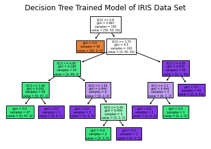

```python
from sklearn.tree import DecisionTreeClassifier
from sklearn.tree import plot_tree

model = DecisionTreeClassifier().fit(X,y)
plot_tree(model, filled=True)
plt.title('Decision Tree Trained Model of IRIS Data Set')
plt.savefig('decision_tree_png.png')
plt.savefig("decision_tree_pdf.pdf")
plt.savefig('decision_tree_tiff.tiff',dpi=300)
plt.show()
```

```python
plt.savefig('decision_tree_png.png', dpi=300)
```

# **Activation Functions and When to Use Them?**

## **What is Activation Fuction.**

Activation functions are an extremely important feature of the artificial neural networks. They basically decide whether a neuron should be activated or not. Whether the information that the neuron is receiving is relevant for the given information or should it be ignored. The activation function is the non linear transformation that we do over the input signal. This transformed output is then sen to the next layer of neurons as input.

## **Types Of of Activation Function**

There are several Types of Activation Function Which arae used in Machine learning and Neural Networks. we gona discuss soeme of them.

1. Identity
2. Binary Step
3. Sigmoid
4. Tanh
5. ReLU
6. Leaky ReLU
7. Softmax

### **Identity function**

An identity function, also called an identity relation or identity map or identity transformation, is a function that always returns the same value that was used as its argument.

### **Binary Step**

A binary step function is generally used in the Perceptron linear classifier. It thresholds the input values to 1 and 0, if they are greater or less than zero, respectively.

### **Sigmoid**

sigmoid function is normally used to refer specifically to the logistic function, also called the logistic sigmoid function

### **Tanh**

A tanh function ensures that the values stay between -1 and 1, thus regulating the output of the neural network. You can see how the same values from above remain between the boundaries allowed by the tanh function.

### **ReLU**

The main reason why ReLu is used is because it is simple, fast, and empirically it seems to work well.ReLU is the most widely used activation function while designing networks today. First things first, the ReLU function is non linear, which means we can easily backpropagate the errors and have multiple layers of neurons being activated by the ReLU function.

### **Leaky ReLU**

Leaky ReLU function is nothing but an improved version of the ReLU function.

### **Softmax**

The softmax function is also a type of sigmoid function but is handy when we are trying to handle classification problems. The sigmoid function as we saw earlier was able to handle just two classes. What shall we do when we are trying to handle multiple classes. Just classifying yes or no for a single class would not help then. The softmax function would squeeze the outputs for each class between 0 and 1 and would also divide by the sum of the outputs. This essentially gives the probability of the input being in a particular class

# Machine Learning

## 09 -Logistic regression and image classification case study

```python
# import Libraries
import numpy as np
import pandas as pd
import matplotlib.pyplot as plt
import seaborn as sns
```

```python
# Importing Online Data Set
from sklearn.datasets import load_digits

digits = load_digits()
```

```python
# Input Variable ya Feature (X)
digits.data.shape

# 1797 pictures, 64 is image size which is = 8x8

# Assigning the image Value name  y
X = digits.data
```

```python
# # Out-put Labeles (y)
digits.target.shape
# Assigning the image Value name  y
y = digits.target
```

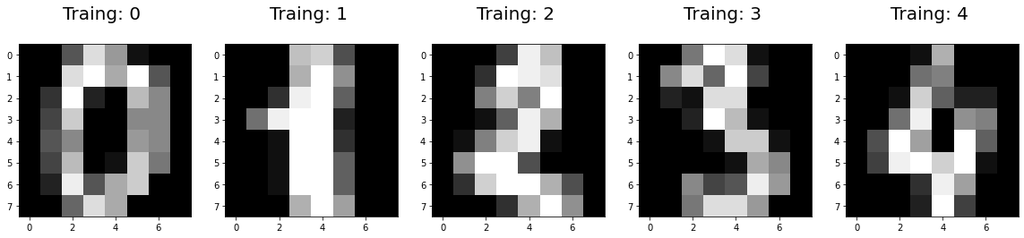

```python
plt.figure(figsize=(20,4))
for index, (image,label) in enumerate(zip(digits.data[0:5],digits.target[0:5])):
    plt.subplot(1,5,index +1)
    plt.imshow(np.reshape(image,(8,8)),cmap=(plt.cm.gray))
    plt.title("Traing: %i \n" % label, fontsize=20)
```

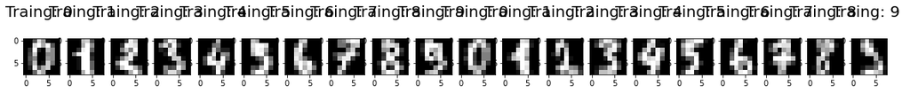

```python
plt.figure(figsize=(20,4))
for index, (image,label) in enumerate(zip(digits.data[0:20],digits.target[0:20])):
    plt.subplot(1,20,index +1)
    plt.imshow(np.reshape(image,(8,8)),cmap=(plt.cm.gray))
    plt.title("Traing: %i \n" % label, fontsize=20)
```

```python
# help(plt)
```

## split the data set

```python
# split the data set

from sklearn.model_selection import train_test_split
x_train, x_test, y_train, y_test = train_test_split(X,y,test_size=0.2,random_state=0)
```

```python
print("Trained Input Data:",x_train.shape)
print("Text Input Data:",x_test.shape)
print("Trained OutPut Data:",y_train.shape)
print("Test Output Data:",y_test.shape)
```

```
Trained Input Data: (1437, 64)
Text Input Data: (360, 64)
Trained OutPut Data: (1437,)
Test Output Data: (360,)
```

## Now we will Train our Model

```python
from sklearn.linear_model import LogisticRegression
model = LogisticRegression().fit(x_train,y_train)
model
```

```
LogisticRegression()
```

## Predict Test Data Set from x_test

```python
model.predict(x_test[0:10]) # we get prediction for 10 value
predictions = model.predict(x_test)
predictions
```

```
array([2, 8, 2, 6, 6, 7, 1, 9, 8, 5, 2, 8, 6, 6, 6, 6, 1, 0, 5, 8, 8, 7,
       8, 4, 7, 5, 4, 9, 2, 9, 4, 7, 6, 8, 9, 4, 3, 1, 0, 1, 8, 6, 7, 7,
       1, 0, 7, 6, 2, 1, 9, 6, 7, 9, 0, 0, 9, 1, 6, 3, 0, 2, 3, 4, 1, 9,
       2, 6, 9, 1, 8, 3, 5, 1, 2, 8, 2, 2, 9, 7, 2, 3, 6, 0, 9, 3, 7, 5,
       1, 2, 9, 9, 3, 1, 4, 7, 4, 8, 5, 8, 5, 5, 2, 5, 9, 0, 7, 1, 4, 7,
       3, 4, 8, 9, 7, 9, 8, 2, 1, 5, 2, 5, 8, 4, 1, 7, 0, 6, 1, 5, 5, 9,
       9, 5, 9, 9, 5, 7, 5, 6, 2, 8, 6, 9, 6, 1, 5, 1, 5, 9, 9, 1, 5, 3,
       6, 1, 8, 9, 8, 7, 6, 7, 6, 5, 6, 0, 8, 8, 9, 8, 6, 1, 0, 4, 1, 6,
       3, 8, 6, 7, 4, 9, 6, 3, 0, 3, 3, 3, 0, 7, 7, 5, 7, 8, 0, 7, 1, 9,
       6, 4, 5, 0, 1, 4, 6, 4, 3, 3, 0, 9, 5, 9, 2, 1, 4, 2, 1, 6, 8, 9,
       2, 4, 9, 3, 7, 6, 2, 3, 3, 1, 6, 9, 3, 6, 3, 3, 2, 0, 7, 6, 1, 1,
       9, 7, 2, 7, 8, 5, 5, 7, 5, 2, 3, 7, 2, 7, 5, 5, 7, 0, 9, 1, 6, 5,
       9, 7, 4, 3, 8, 0, 3, 6, 4, 6, 3, 2, 6, 8, 8, 8, 4, 6, 7, 5, 2, 4,
       5, 3, 2, 4, 6, 9, 4, 5, 4, 3, 4, 6, 2, 9, 0, 1, 7, 2, 0, 9, 6, 0,
       4, 2, 0, 7, 9, 8, 5, 7, 8, 2, 8, 4, 3, 7, 2, 6, 9, 1, 5, 1, 0, 8,
       2, 8, 9, 5, 6, 2, 2, 7, 2, 1, 5, 1, 6, 4, 5, 0, 9, 4, 1, 1, 7, 0,
       8, 9, 0, 5, 4, 3, 8, 8])
```

## Prediction Accurancy Check

```python
# accuracy test

score = model.score(x_test,y_test) # Compare value of x_test with y_Test
print('The Accuracy score is:',score)
```

```
The Accuracy score is: 0.9666666666666667
```